# COVID-19 Data Analysis

2023-03-06

## Import libraries that are needed

```r
library(tidyverse)
library(lubridate)
```

```r
library(dplyr)
library(ggplot2)
library(scales)
```

## Problem Statement

I am analyzing COVID data in this project. I am trying to find what were most affected countries by number of cases and deaths. I would also try to find what is trend of new cases globally. From there, I would create a linear model to predict number of new COVID cases per day globally.

## Data Description

I am using COVID-19 data provided by John Hopkins University. I am using four data files that contain information about number of COVID cases and deaths for US and Globally. This data set contains information like total cases, deaths, province_state, country, date and few other fields that I may not use.

## Load COVID data for US and Global

```r
global_cases_orig <- read_csv("https://raw.githubusercontent.com/CSSEGISandData/COVID-19/master/csse_covid_19_data/csse_covid_19_time_series/time_series_covid19_confirmed_global.csv", show_col_types = FALSE)
global_deaths_orig <- read_csv("https://raw.githubusercontent.com/CSSEGISandData/COVID-19/master/csse_covid_19_data/csse_covid_19_time_series/time_series_covid19_deaths_global.csv", show_col_types = FALSE)
us_cases_orig <- read_csv("https://raw.githubusercontent.com/CSSEGISandData/COVID-19/master/csse_covid_19_data/csse_covid_19_time_series/time_series_covid19_confirmed_US.csv", show_col_types = FALSE)
us_deaths_orig <- read_csv("https://raw.githubusercontent.com/CSSEGISandData/COVID-19/master/csse_covid_19_data/csse_covid_19_time_series/time_series_covid19_deaths_US.csv", show_col_types = FALSE)
```

## Tidy data and combine Cases and Deaths data - Global

```r
global_cases <- global_cases_orig %>% pivot_longer(cols = -c('Province/State',
                                                        'Country/Region',Lat, 'Long'),
                                              names_to = "date",
                                              values_to = "cases") %>%
                select(-c(Lat,Long))

global_cases
```

```
## # A tibble: 329,460 × 4
##    `Province/State` `Country/Region` date    cases
##    <chr>            <chr>            <chr>   <dbl>
##  1 <NA>             Afghanistan      1/22/20     0
##  2 <NA>             Afghanistan      1/23/20     0
##  3 <NA>             Afghanistan      1/24/20     0
##  4 <NA>             Afghanistan      1/25/20     0
##  5 <NA>             Afghanistan      1/26/20     0
##  6 <NA>             Afghanistan      1/27/20     0
##  7 <NA>             Afghanistan      1/28/20     0
##  8 <NA>             Afghanistan      1/29/20     0
##  9 <NA>             Afghanistan      1/30/20     0
## 10 <NA>             Afghanistan      1/31/20     0
## # … with 329,450 more rows
```

```r
global_deaths <- global_deaths_orig %>% pivot_longer(cols = -c('Province/State',
                                                        'Country/Region',Lat, 'Long'),
                                              names_to = "date",
                                              values_to = "deaths") %>%
                select(-c(Lat,Long))
global_deaths
```

```
## # A tibble: 329,460 × 4
##    `Province/State` `Country/Region` date    deaths
##    <chr>            <chr>            <chr>    <dbl>
##  1 <NA>             Afghanistan      1/22/20      0
##  2 <NA>             Afghanistan      1/23/20      0
##  3 <NA>             Afghanistan      1/24/20      0
##  4 <NA>             Afghanistan      1/25/20      0
##  5 <NA>             Afghanistan      1/26/20      0
##  6 <NA>             Afghanistan      1/27/20      0
##  7 <NA>             Afghanistan      1/28/20      0
##  8 <NA>             Afghanistan      1/29/20      0
##  9 <NA>             Afghanistan      1/30/20      0
## 10 <NA>             Afghanistan      1/31/20      0
## # … with 329,450 more rows
```

```r
global_combined <- global_cases %>% full_join(global_deaths) %>%
          rename(Country_Region = 'Country/Region', Province_State = 'Province/State') %>%
          mutate(date = mdy(date))
global_combined
```

```
## # A tibble: 329,460 × 5
##    Province_State Country_Region date       cases deaths
##    <chr>          <chr>          <date>     <dbl>  <dbl>
##  1 <NA>           Afghanistan    2020-01-22     0      0
##  2 <NA>           Afghanistan    2020-01-23     0      0
##  3 <NA>           Afghanistan    2020-01-24     0      0
##  4 <NA>           Afghanistan    2020-01-25     0      0
##  5 <NA>           Afghanistan    2020-01-26     0      0
##  6 <NA>           Afghanistan    2020-01-27     0      0
##  7 <NA>           Afghanistan    2020-01-28     0      0
##  8 <NA>           Afghanistan    2020-01-29     0      0
##  9 <NA>           Afghanistan    2020-01-30     0      0
## 10 <NA>           Afghanistan    2020-01-31     0      0
## # … with 329,450 more rows
```

## Tidy data and combine Cases and Deaths data - US

```r
us_cases <- us_cases_orig %>%
  select(-c(UID, iso2, iso3, code3, FIPS, Lat, Long_))
us_deaths <- us_deaths_orig %>%
  select(-c(UID, iso2, iso3, code3, FIPS, Lat, Long_))

us_cases <- us_cases %>% pivot_longer(cols = -c(Admin2,Province_State,
                                                        Country_Region,Combined_Key),
                                              names_to = "date",
                                              values_to = "cases")

us_cases
```

```
## # A tibble: 3,809,880 × 6
##    Admin2  Province_State Country_Region Combined_Key         date    cases
##    <chr>   <chr>          <chr>          <chr>                <chr>   <dbl>
##  1 Autauga Alabama        US             Autauga, Alabama, US 1/22/20     0
##  2 Autauga Alabama        US             Autauga, Alabama, US 1/23/20     0
##  3 Autauga Alabama        US             Autauga, Alabama, US 1/24/20     0
##  4 Autauga Alabama        US             Autauga, Alabama, US 1/25/20     0
##  5 Autauga Alabama        US             Autauga, Alabama, US 1/26/20     0
##  6 Autauga Alabama        US             Autauga, Alabama, US 1/27/20     0
##  7 Autauga Alabama        US             Autauga, Alabama, US 1/28/20     0
##  8 Autauga Alabama        US             Autauga, Alabama, US 1/29/20     0
##  9 Autauga Alabama        US             Autauga, Alabama, US 1/30/20     0
## 10 Autauga Alabama        US             Autauga, Alabama, US 1/31/20     0
## # … with 3,809,870 more rows
```

```r
us_deaths <- us_deaths %>% pivot_longer(cols = -c('Admin2','Province_State',
                                                        'Country_Region',Combined_Key),
                                              names_to = "date",
                                              values_to = "deaths")
us_deaths
```

```
## # A tibble: 3,813,222 × 6
##    Admin2  Province_State Country_Region Combined_Key         date       deaths
##    <chr>   <chr>          <chr>          <chr>                <chr>       <dbl>
##  1 Autauga Alabama        US             Autauga, Alabama, US Population  55869
##  2 Autauga Alabama        US             Autauga, Alabama, US 1/22/20         0
##  3 Autauga Alabama        US             Autauga, Alabama, US 1/23/20         0
##  4 Autauga Alabama        US             Autauga, Alabama, US 1/24/20         0
##  5 Autauga Alabama        US             Autauga, Alabama, US 1/25/20         0
##  6 Autauga Alabama        US             Autauga, Alabama, US 1/26/20         0
##  7 Autauga Alabama        US             Autauga, Alabama, US 1/27/20         0
##  8 Autauga Alabama        US             Autauga, Alabama, US 1/28/20         0
##  9 Autauga Alabama        US             Autauga, Alabama, US 1/29/20         0
## 10 Autauga Alabama        US             Autauga, Alabama, US 1/30/20         0
## # … with 3,813,212 more rows
```

```r
us_combined <- us_cases %>% full_join(us_deaths) %>%
          mutate(date = mdy(date))
```

[output not shown]

```r
us_combined
```

```
## # A tibble: 3,813,222 × 7
##    Admin2  Province_State Country_Region Combined_Key    date       cases deaths
##    <chr>   <chr>          <chr>          <chr>           <date>     <dbl>  <dbl>
##  1 Autauga Alabama        US             Autauga, Alaba… 2020-01-22     0      0
##  2 Autauga Alabama        US             Autauga, Alaba… 2020-01-23     0      0
##  3 Autauga Alabama        US             Autauga, Alaba… 2020-01-24     0      0
##  4 Autauga Alabama        US             Autauga, Alaba… 2020-01-25     0      0
##  5 Autauga Alabama        US             Autauga, Alaba… 2020-01-26     0      0
##  6 Autauga Alabama        US             Autauga, Alaba… 2020-01-27     0      0
##  7 Autauga Alabama        US             Autauga, Alaba… 2020-01-28     0      0
##  8 Autauga Alabama        US             Autauga, Alaba… 2020-01-29     0      0
##  9 Autauga Alabama        US             Autauga, Alaba… 2020-01-30     0      0
## 10 Autauga Alabama        US             Autauga, Alaba… 2020-01-31     0      0
## # … with 3,813,212 more rows
```

## Filter Global Data

```r
summary(global_combined)
```

```
##  Province_State     Country_Region          date                cases
##  Length:329460      Length:329460      Min.   :2020-01-22   Min.   :        0
##  Class :character   Class :character   1st Qu.:2020-11-01   1st Qu.:      674
##  Mode  :character   Mode  :character   Median :2021-08-13   Median :    14336
##                                        Mean   :2021-08-13   Mean   :   955749
##                                        3rd Qu.:2022-05-25   3rd Qu.:   227878
##                                        Max.   :2023-03-06   Max.   :103655657
##      deaths
##  Min.   :      0
##  1st Qu.:      3
##  Median :    149
##  Mean   :  13353
##  3rd Qu.:   3017
##  Max.   :1122264
```

```r
global_combined <- global_combined %>% filter(cases > 0)

summary(global_combined)
```

```
##  Province_State     Country_Region          date                cases
##  Length:305966      Length:305966      Min.   :2020-01-22   Min.   :        1
##  Class :character   Class :character   1st Qu.:2020-12-11   1st Qu.:     1309
##  Mode  :character   Mode  :character   Median :2021-09-14   Median :    20275
##                                        Mean   :2021-09-10   Mean   :  1029137
##                                        3rd Qu.:2022-06-13   3rd Qu.:   270739
##                                        Max.   :2023-03-06   Max.   :103655657
##      deaths
##  Min.   :      0
##  1st Qu.:      7
##  Median :    213
##  Mean   :  14378
##  3rd Qu.:   3649
##  Max.   :1122264
```

```r
#global_combined %>% filter(cases > 100000000)
```

## Rename some columns for consistency across data sets

```r
names(global_combined)[1:2] <- c("State", "Country")
names(us_combined)[1:3] <- c("County","State", "Country")

global_combined
```

```
## # A tibble: 305,966 × 5
##    State Country     date       cases deaths
##    <chr> <chr>       <date>     <dbl>  <dbl>
##  1 <NA>  Afghanistan 2020-02-24     5      0
##  2 <NA>  Afghanistan 2020-02-25     5      0
##  3 <NA>  Afghanistan 2020-02-26     5      0
##  4 <NA>  Afghanistan 2020-02-27     5      0
##  5 <NA>  Afghanistan 2020-02-28     5      0
##  6 <NA>  Afghanistan 2020-02-29     5      0
##  7 <NA>  Afghanistan 2020-03-01     5      0
##  8 <NA>  Afghanistan 2020-03-02     5      0
##  9 <NA>  Afghanistan 2020-03-03     5      0
## 10 <NA>  Afghanistan 2020-03-04     5      0
## # … with 305,956 more rows
```

```r
us_combined
```

```
## # A tibble: 3,813,222 × 7
##    County  State   Country Combined_Key         date       cases deaths
##    <chr>   <chr>   <chr>   <chr>                <date>     <dbl>  <dbl>
##  1 Autauga Alabama US      Autauga, Alabama, US 2020-01-22     0      0
##  2 Autauga Alabama US      Autauga, Alabama, US 2020-01-23     0      0
##  3 Autauga Alabama US      Autauga, Alabama, US 2020-01-24     0      0
##  4 Autauga Alabama US      Autauga, Alabama, US 2020-01-25     0      0
##  5 Autauga Alabama US      Autauga, Alabama, US 2020-01-26     0      0
##  6 Autauga Alabama US      Autauga, Alabama, US 2020-01-27     0      0
##  7 Autauga Alabama US      Autauga, Alabama, US 2020-01-28     0      0
##  8 Autauga Alabama US      Autauga, Alabama, US 2020-01-29     0      0
##  9 Autauga Alabama US      Autauga, Alabama, US 2020-01-30     0      0
## 10 Autauga Alabama US      Autauga, Alabama, US 2020-01-31     0      0
## # … with 3,813,212 more rows
```

## Group Data by Daily

```r
global_combined_daily <- global_combined %>%
  group_by(Country, date) %>%
  summarize(cases = sum(cases),deaths = sum(deaths))
global_combined_daily <- global_combined_daily %>%
          mutate(date = as.Date(date, format = "%m/%d/%y"))

global_combined_daily
```

```
## # A tibble: 213,510 × 4
## # Groups:   Country [201]
##    Country     date       cases deaths
##    <chr>       <date>     <dbl>  <dbl>
##  1 Afghanistan 2020-02-24     5      0
##  2 Afghanistan 2020-02-25     5      0
##  3 Afghanistan 2020-02-26     5      0
##  4 Afghanistan 2020-02-27     5      0
##  5 Afghanistan 2020-02-28     5      0
##  6 Afghanistan 2020-02-29     5      0
##  7 Afghanistan 2020-03-01     5      0
##  8 Afghanistan 2020-03-02     5      0
##  9 Afghanistan 2020-03-03     5      0
## 10 Afghanistan 2020-03-04     5      0
## # … with 213,500 more rows
```

```r
us_combined_daily <- us_combined %>%
  group_by(State, date) %>%
  summarize(cases = sum(cases),deaths = sum(deaths))
us_combined_daily <- us_combined_daily %>%
          mutate(date = as.Date(date, format = "%m/%d/%y"))

us_combined_daily
```

```
## # A tibble: 66,178 × 4
## # Groups:   State [58]
##    State   date       cases deaths
##    <chr>   <date>     <dbl>  <dbl>
##  1 Alabama 2020-01-22     0      0
##  2 Alabama 2020-01-23     0      0
##  3 Alabama 2020-01-24     0      0
##  4 Alabama 2020-01-25     0      0
##  5 Alabama 2020-01-26     0      0
##  6 Alabama 2020-01-27     0      0
##  7 Alabama 2020-01-28     0      0
##  8 Alabama 2020-01-29     0      0
##  9 Alabama 2020-01-30     0      0
## 10 Alabama 2020-01-31     0      0
## # … with 66,168 more rows
```

## Let us find Top 5 Countries by Total Number of Cases

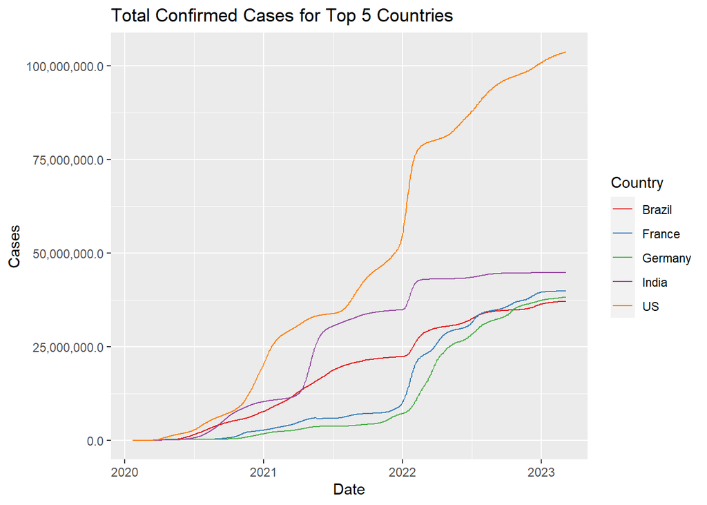

```r
# Get top 5 countries by total confirmed cases
top_countries <- global_combined_daily %>%
  group_by(Country) %>%
  summarize(Total_Confirmed = sum(cases)) %>%
  arrange(desc(Total_Confirmed)) %>%
  slice_head(n = 5)

# Filter data for top 5 countries
top_data <- global_combined_daily %>%
  filter(Country %in% top_countries$Country)

# Plot daily confirmed cases for top 5 countries
ggplot() +
  geom_line(data = top_data, aes(x = as.Date(date), y = cases, color = Country)) +
  scale_color_brewer(palette = "Set1") +
  scale_y_continuous(labels = comma_format(big.mark = ",", accuracy = 0.1)) +
  labs(x = "Date", y = "Cases",
       title = "Total Confirmed Cases for Top 5 Countries",
       color = "Country")
```

## Let us find Top 5 Countries by Total Number of Deaths

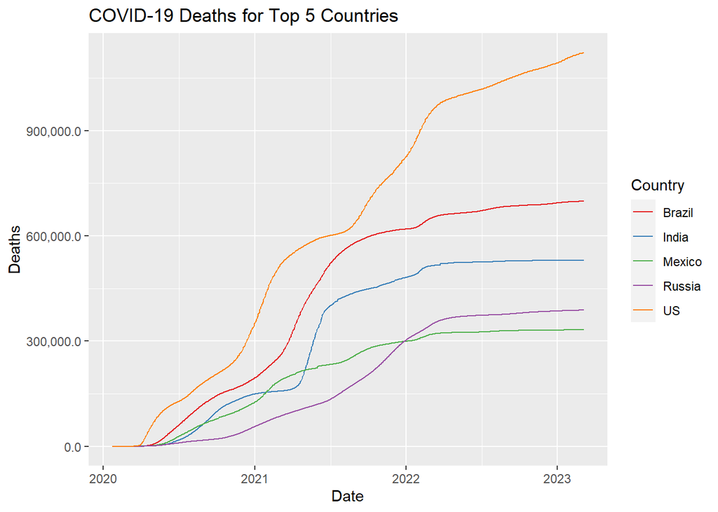

```r
# Get top 5 countries by total deaths
top_countries <- global_combined_daily %>%
  group_by(Country) %>%
  summarize(Total_Death = sum(deaths)) %>%
  arrange(desc(Total_Death)) %>%
  slice_head(n = 5)

# Filter data for top 5 countries
top_data <- global_combined_daily %>%
  filter(Country %in% top_countries$Country)

# Plot deaths for top 5 countries
ggplot() +
  geom_line(data = top_data, aes(x = as.Date(date), y = deaths, color = Country)) +
  scale_color_brewer(palette = "Set1") +
  scale_y_continuous(labels = comma_format(big.mark = ",", accuracy = 0.1)) +
  labs(x = "Date", y = "Deaths",
       title = "COVID-19 Deaths for Top 5 Countries",
       color = "Country")
```

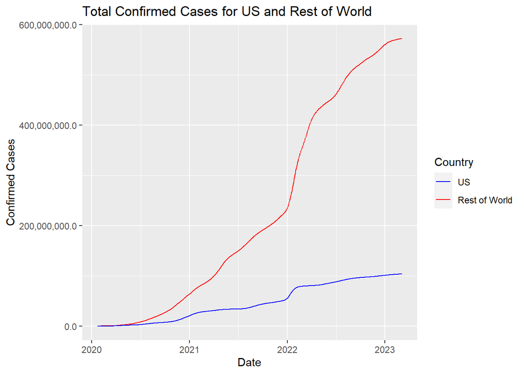

```r
# Filter data for US and rest of world
us_data <- global_combined_daily %>%
  filter(Country == "US")
world_data <- global_combined_daily %>%
  filter(Country != "US") %>%
  group_by(date) %>%
  summarize(cases = sum(cases)) %>%
  mutate(Country = "Rest of World")

# Combine data for plotting
plot_data <- bind_rows(us_data, world_data)

# Plot daily confirmed cases for US and rest of world
ggplot(plot_data, aes(x = as.Date(date), y = cases, color = Country)) +
  geom_line() +
  scale_y_continuous(labels = comma_format(big.mark = ",", accuracy = 0.1)) +
  scale_color_manual(values = c("US" = "blue", "Rest of World" = "red")) +
  labs(x = "Date", y = "Confirmed Cases",
       title = "Total Confirmed Cases for US and Rest of World",
       color = "Country")
```

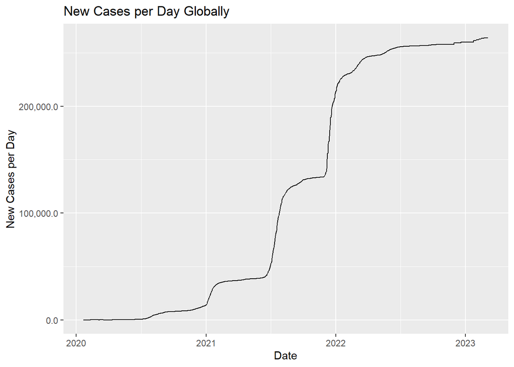

```r
# Calculate new cases per day global
cases_data <- global_combined_daily %>%
  group_by(date) %>%
  summarize(new_cases = sum(cases) - sum(lag(cases, default = 0)))

# Plot new cases per day for global
ggplot() +
  scale_y_continuous(labels = comma_format(big.mark = ",", accuracy = 0.1)) +
  geom_line(data = cases_data, aes(x = date, y = new_cases)) +
  labs(x = "Date", y = "New Cases per Day",
       title = "New Cases per Day Globally")
```

### We can see big spikes in second half of 2021 in above plot

## Model to predict number of new cases globally per day

```r
global_data_new_cases <- global_combined_daily %>%
  arrange(date) %>%
  group_by(date) %>%
  summarize(cases = sum(cases)) %>%
  mutate(new_cases = cases - lag(cases, default = 0)) %>%
  select(date, new_cases)

train_size <- floor(0.8 * nrow(global_data_new_cases))
train_data <- global_data_new_cases %>%
  slice(1:train_size)
test_data <- global_data_new_cases %>%
  slice((train_size+1):nrow(global_data_new_cases))

head(train_data)
```

```
## # A tibble: 6 × 2
##   date       new_cases
##   <date>         <dbl>
## 1 2020-01-22       557
## 2 2020-01-23       100
## 3 2020-01-24       287
## 4 2020-01-25       493
## 5 2020-01-26       683
## 6 2020-01-27       809
```

```r
head(test_data)
```

```
## # A tibble: 6 × 2
##   date       new_cases
##   <date>         <dbl>
## 1 2022-07-22   1095295
## 2 2022-07-23    636819
## 3 2022-07-24    551089
## 4 2022-07-25    973697
## 5 2022-07-26   1196660
## 6 2022-07-27   1426623
```

```r
lm_model <- lm(new_cases ~ lag(new_cases,1), data = train_data)
summary(lm_model)
```

```
##
## Call:
## lm(formula = new_cases ~ lag(new_cases, 1), data = train_data)
##
## Residuals:
##      Min       1Q   Median       3Q      Max
## -1000592   -54768   -20713    30442  1759714
##
## Coefficients:
##                    Estimate Std. Error t value Pr(>|t|)
## (Intercept)       3.270e+04  9.338e+03   3.502 0.000484 ***
## lag(new_cases, 1) 9.495e-01  1.039e-02  91.357  < 2e-16 ***
## ---
## Signif. codes:  0 '***' 0.001 '**' 0.01 '*' 0.05 '.' 0.1 ' ' 1
##
## Residual standard error: 203300 on 909 degrees of freedom
##   (1 observation deleted due to missingness)
## Multiple R-squared:  0.9018, Adjusted R-squared:  0.9017
## F-statistic:  8346 on 1 and 909 DF,  p-value: < 2.2e-16
```

```r
predictions <- predict(lm_model, newdata = test_data, type = "response")

predicted_data <- test_data %>% mutate(pred = floor(predictions))

predicted_data
```

```
## # A tibble: 228 × 3
##    date       new_cases    pred
##    <date>         <dbl>   <dbl>
##  1 2022-07-22   1095295      NA
##  2 2022-07-23    636819 1072674
##  3 2022-07-24    551089  637355
##  4 2022-07-25    973697  555955
##  5 2022-07-26   1196660  957218
##  6 2022-07-27   1426623 1168919
##  7 2022-07-28   1116133 1387267
##  8 2022-07-29   1375405 1092460
##  9 2022-07-30    576251 1338636
## 10 2022-07-31    544757  579846
## # … with 218 more rows
```

## Conclusion and Possible Bias

Top 5 countries with most cases included US, India, France, Germany and Brazil. As this data is all the way upto March 2023, we have to look at data for last one year bit differently. Not all countries may be reporting cases same way, there are self tests going on that are not reported.

Top 5 countries with most COVID related deaths included US, Brazil, India, Russia and Mexico. France and Germany are not in top 5 for number of deaths.

Globally, we had couple of big spikes in between 2021 and 2022, especially in second half of 2021.

### Possible Bias:

There are some sources of bias in this data. Not all countries may have reported all the cases. This may be because of multiple reasons like testing facilities (especially early on), political sensitivity to the numbers, not enough infrastructure to get local data to central databases. On the other side of equation, there may have been cases where numbers were inflated by hospitals in some counries by tagging some cases as COVID to get more money from insurance. Chances of this bias would be less compared to under reporting by countries but not totally ruled out.